# Optimal Treatment Analysis

## Outcome Variable

**Outcome Variable:** whz

## Predictor Variables

**Intervention Variable:** brthmon

**Adjustment Set:**

unadjusted

## Stratifying Variables

The analysis was stratified on these variable(s):

- agecat
- studyid
- country

## Data Summary

| agecat | studyid | country | brthmon | n_cell | n |
| --- | --- | --- | --- | --- | --- |
| Birth | ki0047075b-MAL-ED | BANGLADESH | 1 | 19 | 215 |
| Birth | ki0047075b-MAL-ED | BANGLADESH | 2 | 21 | 215 |
| Birth | ki0047075b-MAL-ED | BANGLADESH | 3 | 21 | 215 |
| Birth | ki0047075b-MAL-ED | BANGLADESH | 4 | 19 | 215 |
| Birth | ki0047075b-MAL-ED | BANGLADESH | 5 | 17 | 215 |
| Birth | ki0047075b-MAL-ED | BANGLADESH | 6 | 7 | 215 |
| Birth | ki0047075b-MAL-ED | BANGLADESH | 7 | 13 | 215 |
| Birth | ki0047075b-MAL-ED | BANGLADESH | 8 | 23 | 215 |
| Birth | ki0047075b-MAL-ED | BANGLADESH | 9 | 16 | 215 |
| Birth | ki0047075b-MAL-ED | BANGLADESH | 10 | 20 | 215 |
| Birth | ki0047075b-MAL-ED | BANGLADESH | 11 | 15 | 215 |
| Birth | ki0047075b-MAL-ED | BANGLADESH | 12 | 24 | 215 |
| Birth | ki0047075b-MAL-ED | BRAZIL | 1 | 5 | 62 |
| Birth | ki0047075b-MAL-ED | BRAZIL | 2 | 10 | 62 |
| Birth | ki0047075b-MAL-ED | BRAZIL | 3 | 7 | 62 |
| Birth | ki0047075b-MAL-ED | BRAZIL | 4 | 4 | 62 |
| Birth | ki0047075b-MAL-ED | BRAZIL | 5 | 1 | 62 |
| Birth | ki0047075b-MAL-ED | BRAZIL | 6 | 5 | 62 |
| Birth | ki0047075b-MAL-ED | BRAZIL | 7 | 6 | 62 |
| Birth | ki0047075b-MAL-ED | BRAZIL | 8 | 6 | 62 |
| Birth | ki0047075b-MAL-ED | BRAZIL | 9 | 5 | 62 |
| Birth | ki0047075b-MAL-ED | BRAZIL | 10 | 5 | 62 |
| Birth | ki0047075b-MAL-ED | BRAZIL | 11 | 4 | 62 |
| Birth | ki0047075b-MAL-ED | BRAZIL | 12 | 4 | 62 |
| Birth | ki0047075b-MAL-ED | INDIA | 1 | 2 | 45 |
| Birth | ki0047075b-MAL-ED | INDIA | 2 | 6 | 45 |
| Birth | ki0047075b-MAL-ED | INDIA | 3 | 3 | 45 |
| Birth | ki0047075b-MAL-ED | INDIA | 4 | 5 | 45 |
| Birth | ki0047075b-MAL-ED | INDIA | 5 | 4 | 45 |
| Birth | ki0047075b-MAL-ED | INDIA | 6 | 2 | 45 |

[output cut: 810 more lines]

The following strata were considered:

- agecat: 24 months, studyid: ki0047075b-MAL-ED, country: BANGLADESH
- agecat: 24 months, studyid: ki0047075b-MAL-ED, country: BRAZIL
- agecat: 24 months, studyid: ki0047075b-MAL-ED, country: INDIA
- agecat: 24 months, studyid: ki0047075b-MAL-ED, country: NEPAL
- agecat: 24 months, studyid: ki0047075b-MAL-ED, country: PERU
- agecat: 24 months, studyid: ki0047075b-MAL-ED, country: SOUTH AFRICA
- agecat: 24 months, studyid: ki0047075b-MAL-ED, country: TANZANIA, UNITED REPUBLIC OF
- agecat: 24 months, studyid: ki1000108-CMC-V-BCS-2002, country: INDIA
- agecat: 24 months, studyid: ki1000108-IRC, country: INDIA
- agecat: 24 months, studyid: ki1000109-EE, country: PAKISTAN
- agecat: 24 months, studyid: ki1017093-NIH-Birth, country: BANGLADESH
- agecat: 24 months, studyid: ki1017093b-PROVIDE, country: BANGLADESH
- agecat: 24 months, studyid: ki1066203-TanzaniaChild2, country: TANZANIA, UNITED REPUBLIC OF
- agecat: 24 months, studyid: ki1101329-Keneba, country: GAMBIA
- agecat: 24 months, studyid: ki1113344-GMS-Nepal, country: NEPAL
- agecat: 24 months, studyid: ki1114097-CMIN, country: BANGLADESH
- agecat: 24 months, studyid: ki1114097-CONTENT, country: PERU
- agecat: 24 months, studyid: ki1119695-PROBIT, country: BELARUS
- agecat: 24 months, studyid: ki1126311-ZVITAMBO, country: ZIMBABWE
- agecat: 24 months, studyid: ki1148112-LCNI-5, country: MALAWI
- agecat: 24 months, studyid: kiGH5241-JiVitA-3, country: BANGLADESH
- agecat: 24 months, studyid: kiGH5241-JiVitA-4, country: BANGLADESH
- agecat: 6 months, studyid: ki0047075b-MAL-ED, country: BANGLADESH
- agecat: 6 months, studyid: ki0047075b-MAL-ED, country: BRAZIL
- agecat: 6 months, studyid: ki0047075b-MAL-ED, country: INDIA
- agecat: 6 months, studyid: ki0047075b-MAL-ED, country: NEPAL
- agecat: 6 months, studyid: ki0047075b-MAL-ED, country: PERU
- agecat: 6 months, studyid: ki0047075b-MAL-ED, country: SOUTH AFRICA
- agecat: 6 months, studyid: ki0047075b-MAL-ED, country: TANZANIA, UNITED REPUBLIC OF
- agecat: 6 months, studyid: ki1000108-CMC-V-BCS-2002, country: INDIA
- agecat: 6 months, studyid: ki1000108-IRC, country: INDIA
- agecat: 6 months, studyid: ki1000109-EE, country: PAKISTAN
- agecat: 6 months, studyid: ki1000109-ResPak, country: PAKISTAN
- agecat: 6 months, studyid: ki1000304b-SAS-CompFeed, country: INDIA
- agecat: 6 months, studyid: ki1000304b-SAS-FoodSuppl, country: INDIA
- agecat: 6 months, studyid: ki1017093-NIH-Birth, country: BANGLADESH
- agecat: 6 months, studyid: ki1017093b-PROVIDE, country: BANGLADESH
- agecat: 6 months, studyid: ki1066203-TanzaniaChild2, country: TANZANIA, UNITED REPUBLIC OF
- agecat: 6 months, studyid: ki1101329-Keneba, country: GAMBIA
- agecat: 6 months, studyid: ki1112895-Guatemala BSC, country: GUATEMALA
- agecat: 6 months, studyid: ki1113344-GMS-Nepal, country: NEPAL
- agecat: 6 months, studyid: ki1114097-CMIN, country: BANGLADESH
- agecat: 6 months, studyid: ki1114097-CONTENT, country: PERU
- agecat: 6 months, studyid: ki1119695-PROBIT, country: BELARUS
- agecat: 6 months, studyid: ki1126311-ZVITAMBO, country: ZIMBABWE
- agecat: 6 months, studyid: ki1148112-LCNI-5, country: MALAWI
- agecat: 6 months, studyid: kiGH5241-JiVitA-3, country: BANGLADESH
- agecat: 6 months, studyid: kiGH5241-JiVitA-4, country: BANGLADESH
- agecat: Birth, studyid: ki0047075b-MAL-ED, country: BANGLADESH
- agecat: Birth, studyid: ki0047075b-MAL-ED, country: BRAZIL
- agecat: Birth, studyid: ki0047075b-MAL-ED, country: INDIA
- agecat: Birth, studyid: ki0047075b-MAL-ED, country: NEPAL
- agecat: Birth, studyid: ki0047075b-MAL-ED, country: PERU
- agecat: Birth, studyid: ki0047075b-MAL-ED, country: SOUTH AFRICA
- agecat: Birth, studyid: ki0047075b-MAL-ED, country: TANZANIA, UNITED REPUBLIC OF
- agecat: Birth, studyid: ki1000108-CMC-V-BCS-2002, country: INDIA
- agecat: Birth, studyid: ki1000108-IRC, country: INDIA
- agecat: Birth, studyid: ki1000109-EE, country: PAKISTAN
- agecat: Birth, studyid: ki1000109-ResPak, country: PAKISTAN
- agecat: Birth, studyid: ki1000304b-SAS-CompFeed, country: INDIA
- agecat: Birth, studyid: ki1017093-NIH-Birth, country: BANGLADESH
- agecat: Birth, studyid: ki1017093b-PROVIDE, country: BANGLADESH
- agecat: Birth, studyid: ki1101329-Keneba, country: GAMBIA
- agecat: Birth, studyid: ki1113344-GMS-Nepal, country: NEPAL
- agecat: Birth, studyid: ki1114097-CMIN, country: BANGLADESH
- agecat: Birth, studyid: ki1114097-CONTENT, country: PERU
- agecat: Birth, studyid: ki1119695-PROBIT, country: BELARUS
- agecat: Birth, studyid: ki1126311-ZVITAMBO, country: ZIMBABWE
- agecat: Birth, studyid: kiGH5241-JiVitA-3, country: BANGLADESH
- agecat: Birth, studyid: kiGH5241-JiVitA-4, country: BANGLADESH

### Dropped Strata

Some strata were dropped due to rare outcomes:

- agecat: Birth, studyid: ki0047075b-MAL-ED, country: BRAZIL
- agecat: Birth, studyid: ki0047075b-MAL-ED, country: INDIA
- agecat: Birth, studyid: ki0047075b-MAL-ED, country: NEPAL
- agecat: Birth, studyid: ki0047075b-MAL-ED, country: SOUTH AFRICA
- agecat: Birth, studyid: ki0047075b-MAL-ED, country: TANZANIA, UNITED REPUBLIC OF
- agecat: Birth, studyid: ki1000108-CMC-V-BCS-2002, country: INDIA
- agecat: Birth, studyid: ki1000109-EE, country: PAKISTAN
- agecat: Birth, studyid: ki1000109-ResPak, country: PAKISTAN
- agecat: Birth, studyid: ki1113344-GMS-Nepal, country: NEPAL
- agecat: Birth, studyid: ki1114097-CMIN, country: BANGLADESH
- agecat: Birth, studyid: ki1114097-CONTENT, country: PERU
- agecat: Birth, studyid: kiGH5241-JiVitA-4, country: BANGLADESH
- agecat: 6 months, studyid: ki1000109-EE, country: PAKISTAN
- agecat: 6 months, studyid: ki1000109-ResPak, country: PAKISTAN
- agecat: 6 months, studyid: ki1000304b-SAS-FoodSuppl, country: INDIA
- agecat: 6 months, studyid: ki1113344-GMS-Nepal, country: NEPAL
- agecat: 6 months, studyid: kiGH5241-JiVitA-4, country: BANGLADESH
- agecat: 24 months, studyid: ki1000109-EE, country: PAKISTAN
- agecat: 24 months, studyid: ki1066203-TanzaniaChild2, country: TANZANIA, UNITED REPUBLIC OF
- agecat: 24 months, studyid: ki1113344-GMS-Nepal, country: NEPAL
- agecat: 24 months, studyid: ki1126311-ZVITAMBO, country: ZIMBABWE
- agecat: 24 months, studyid: kiGH5241-JiVitA-4, country: BANGLADESH

## Methods Detail

We’re interested in the causal parameters $E[Y_a]$ for all values of $a \in \mathcal{A}$. These parameters represent the mean outcome if, possibly contrary to fact, we intervened to set all units to have $A=a$. Under the randomization and positivity assumptions, these are identified by the statistical parameters $\psi_a=E_W[E_{Y|A,W}(Y|A=a,W)]$. In addition, we’re interested in the mean of $Y$, $E[Y]$ under no intervention (the observed mean). We will estimate these parameters by using SuperLearner to fit the relevant likelihood factors – $E_{Y|A,W}(Y|A=a,W)$ and $p(A=a|W)$, and then updating our likelihood fit using a joint TMLE.

For unadjusted analyses ($W=\{\}$), initial likelihoods were estimated using Lrnr_glm to estimate the simple $E(Y|A)$ and Lrnr_mean to estimate $p(A)$. For adjusted analyses, a small library containing Lrnr_glmnet, Lrnr_xgboost, and Lrnr_mean was used.

Having estimated these parameters, we will then use the delta method to estimate relative risks and attributable risks relative to a prespecified baseline level of $A$.

# Results Detail

## Results Plots

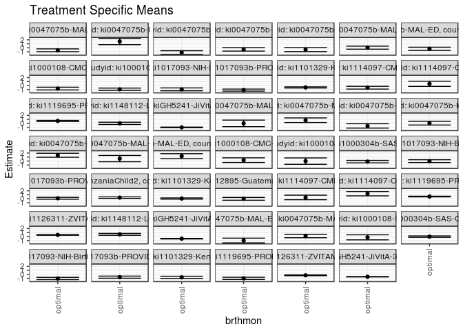

## Results Table

### Parameter: TSM

| agecat | studyid | country | intervention_level | baseline_level | estimate | ci_lower | ci_upper |
| --- | --- | --- | --- | --- | --- | --- | --- |
| Birth | ki0047075b-MAL-ED | BANGLADESH | optimal | observed | -0.9980888 | -1.5869684 | -0.4092092 |
| Birth | ki0047075b-MAL-ED | PERU | optimal | observed | 0.1241114 | -0.3066739 | 0.5548966 |
| Birth | ki1000108-IRC | INDIA | optimal | observed | -0.2043860 | -0.8401510 | 0.4313790 |
| Birth | ki1000304b-SAS-CompFeed | INDIA | optimal | observed | -0.0232810 | -0.2035320 | 0.1569700 |
| Birth | ki1017093-NIH-Birth | BANGLADESH | optimal | observed | -1.0621141 | -1.3446221 | -0.7796062 |
| Birth | ki1017093b-PROVIDE | BANGLADESH | optimal | observed | -0.7206041 | -0.9900455 | -0.4511627 |
| Birth | ki1101329-Keneba | GAMBIA | optimal | observed | -0.7676299 | -1.0420315 | -0.4932283 |
| Birth | ki1119695-PROBIT | BELARUS | optimal | observed | -1.0232836 | -1.3051544 | -0.7414127 |
| Birth | ki1126311-ZVITAMBO | ZIMBABWE | optimal | observed | -0.2608224 | -0.3562750 | -0.1653698 |
| Birth | kiGH5241-JiVitA-3 | BANGLADESH | optimal | observed | -0.6229960 | -0.6754914 | -0.5705007 |
| 6 months | ki0047075b-MAL-ED | BANGLADESH | optimal | observed | -0.0239637 | -0.8459700 | 0.7980426 |
| 6 months | ki0047075b-MAL-ED | BRAZIL | optimal | observed | 0.7744436 | 0.1974792 | 1.3514081 |
| 6 months | ki0047075b-MAL-ED | INDIA | optimal | observed | -0.6580900 | -1.2042401 | -0.1119398 |
| 6 months | ki0047075b-MAL-ED | NEPAL | optimal | observed | 0.0368788 | -0.4321804 | 0.5059380 |
| 6 months | ki0047075b-MAL-ED | PERU | optimal | observed | 1.4531513 | 0.9512598 | 1.9550428 |
| 6 months | ki0047075b-MAL-ED | SOUTH AFRICA | optimal | observed | 0.6104856 | -0.1807033 | 1.4016745 |
| 6 months | ki0047075b-MAL-ED | TANZANIA, UNITED REPUBLIC OF | optimal | observed | 1.2238460 | 0.6031717 | 1.8445202 |
| 6 months | ki1000108-CMC-V-BCS-2002 | INDIA | optimal | observed | 0.2186586 | -0.3612703 | 0.7985876 |
| 6 months | ki1000108-IRC | INDIA | optimal | observed | -0.0160437 | -0.8103841 | 0.7782968 |
| 6 months | ki1000304b-SAS-CompFeed | INDIA | optimal | observed | -0.1453874 | -0.4532389 | 0.1624642 |
| 6 months | ki1017093-NIH-Birth | BANGLADESH | optimal | observed | -0.0209651 | -0.3725727 | 0.3306425 |
| 6 months | ki1017093b-PROVIDE | BANGLADESH | optimal | observed | 0.1283531 | -0.1133080 | 0.3700143 |
| 6 months | ki1066203-TanzaniaChild2 | TANZANIA, UNITED REPUBLIC OF | optimal | observed | 0.2883434 | 0.0972691 | 0.4794177 |
| 6 months | ki1101329-Keneba | GAMBIA | optimal | observed | 0.0627747 | -0.0884930 | 0.2140425 |
| 6 months | ki1112895-Guatemala BSC | GUATEMALA | optimal | observed | -0.0135643 | -0.3608111 | 0.3336824 |
| 6 months | ki1114097-CMIN | BANGLADESH | optimal | observed | 0.3380065 | -0.2351316 | 0.9111446 |
| 6 months | ki1114097-CONTENT | PERU | optimal | observed | 1.2818795 | 0.7346087 | 1.8291504 |
| 6 months | ki1119695-PROBIT | BELARUS | optimal | observed | 0.5661851 | 0.4806740 | 0.6516962 |
| 6 months | ki1126311-ZVITAMBO | ZIMBABWE | optimal | observed | 0.4081939 | 0.3141394 | 0.5022484 |
| 6 months | ki1148112-LCNI-5 | MALAWI | optimal | observed | 0.5508930 | 0.3179091 | 0.7838770 |
| 6 months | kiGH5241-JiVitA-3 | BANGLADESH | optimal | observed | -0.5376549 | -0.6097773 | -0.4655325 |
| 24 months | ki0047075b-MAL-ED | BANGLADESH | optimal | observed | -0.6290564 | -0.9806100 | -0.2775028 |
| 24 months | ki0047075b-MAL-ED | BRAZIL | optimal | observed | 1.5921335 | 0.7876513 | 2.3966157 |
| 24 months | ki0047075b-MAL-ED | INDIA | optimal | observed | -1.1913142 | -1.6538959 | -0.7287324 |
| 24 months | ki0047075b-MAL-ED | NEPAL | optimal | observed | -0.4026788 | -0.8248376 | 0.0194799 |
| 24 months | ki0047075b-MAL-ED | PERU | optimal | observed | -0.4560396 | -0.9610039 | 0.0489247 |
| 24 months | ki0047075b-MAL-ED | SOUTH AFRICA | optimal | observed | 0.0411304 | -0.3398688 | 0.4221297 |
| 24 months | ki0047075b-MAL-ED | TANZANIA, UNITED REPUBLIC OF | optimal | observed | -0.2513715 | -0.6549294 | 0.1521864 |
| 24 months | ki1000108-CMC-V-BCS-2002 | INDIA | optimal | observed | -0.7644892 | -1.1107825 | -0.4181959 |
| 24 months | ki1000108-IRC | INDIA | optimal | observed | -0.9284292 | -1.2171730 | -0.6396855 |
| 24 months | ki1017093-NIH-Birth | BANGLADESH | optimal | observed | -0.9558674 | -1.3186223 | -0.5931126 |
| 24 months | ki1017093b-PROVIDE | BANGLADESH | optimal | observed | -1.1415445 | -1.3991296 | -0.8839594 |
| 24 months | ki1101329-Keneba | GAMBIA | optimal | observed | -0.4730528 | -0.6156268 | -0.3304788 |
| 24 months | ki1114097-CMIN | BANGLADESH | optimal | observed | -0.5370314 | -0.8838710 | -0.1901918 |
| 24 months | ki1114097-CONTENT | PERU | optimal | observed | 0.4319033 | -0.2124651 | 1.0762716 |
| 24 months | ki1119695-PROBIT | BELARUS | optimal | observed | 0.5927425 | 0.4608110 | 0.7246740 |
| 24 months | ki1148112-LCNI-5 | MALAWI | optimal | observed | -0.0121530 | -0.2975046 | 0.2731985 |
| 24 months | kiGH5241-JiVitA-3 | BANGLADESH | optimal | observed | -1.0287909 | -1.1018964 | -0.9556853 |

### Parameter: E(Y)

| agecat | studyid | country | intervention_level | baseline_level | estimate | ci_lower | ci_upper |
| --- | --- | --- | --- | --- | --- | --- | --- |
| Birth | ki0047075b-MAL-ED | BANGLADESH | observed | observed | -0.9412093 | -1.0864308 | -0.7959878 |
| Birth | ki0047075b-MAL-ED | PERU | observed | observed | -0.0520175 | -0.1725298 | 0.0684947 |
| Birth | ki1000108-IRC | INDIA | observed | observed | -1.0105831 | -1.1973019 | -0.8238643 |
| Birth | ki1000304b-SAS-CompFeed | INDIA | observed | observed | -0.6700453 | -0.8474950 | -0.4925957 |
| Birth | ki1017093-NIH-Birth | BANGLADESH | observed | observed | -1.3499217 | -1.4444634 | -1.2553801 |
| Birth | ki1017093b-PROVIDE | BANGLADESH | observed | observed | -1.2984586 | -1.3752758 | -1.2216415 |
| Birth | ki1101329-Keneba | GAMBIA | observed | observed | -1.2349454 | -1.2972413 | -1.1726496 |
| Birth | ki1119695-PROBIT | BELARUS | observed | observed | -1.1448633 | -1.3544229 | -0.9353037 |
| Birth | ki1126311-ZVITAMBO | ZIMBABWE | observed | observed | -0.5154897 | -0.5413479 | -0.4896314 |
| Birth | kiGH5241-JiVitA-3 | BANGLADESH | observed | observed | -0.7501567 | -0.7680049 | -0.7323085 |
| 6 months | ki0047075b-MAL-ED | BANGLADESH | observed | observed | -0.1383956 | -0.2672708 | -0.0095204 |
| 6 months | ki0047075b-MAL-ED | BRAZIL | observed | observed | 0.9717225 | 0.8073791 | 1.1360658 |
| 6 months | ki0047075b-MAL-ED | INDIA | observed | observed | -0.7082698 | -0.8347304 | -0.5818092 |
| 6 months | ki0047075b-MAL-ED | NEPAL | observed | observed | 0.1110452 | -0.0202712 | 0.2423616 |
| 6 months | ki0047075b-MAL-ED | PERU | observed | observed | 1.0568987 | 0.9352990 | 1.1784983 |
| 6 months | ki0047075b-MAL-ED | SOUTH AFRICA | observed | observed | 0.5427231 | 0.3906363 | 0.6948099 |
| 6 months | ki0047075b-MAL-ED | TANZANIA, UNITED REPUBLIC OF | observed | observed | 0.5362213 | 0.4049390 | 0.6675036 |
| 6 months | ki1000108-CMC-V-BCS-2002 | INDIA | observed | observed | -0.5026766 | -0.6536848 | -0.3516685 |
| 6 months | ki1000108-IRC | INDIA | observed | observed | -0.5989297 | -0.7344491 | -0.4634104 |
| 6 months | ki1000304b-SAS-CompFeed | INDIA | observed | observed | -0.6657084 | -0.8024377 | -0.5289791 |
| 6 months | ki1017093-NIH-Birth | BANGLADESH | observed | observed | -0.4474038 | -0.5378167 | -0.3569909 |
| 6 months | ki1017093b-PROVIDE | BANGLADESH | observed | observed | -0.1990907 | -0.2817968 | -0.1163845 |
| 6 months | ki1066203-TanzaniaChild2 | TANZANIA, UNITED REPUBLIC OF | observed | observed | 0.0809332 | 0.0282644 | 0.1336020 |
| 6 months | ki1101329-Keneba | GAMBIA | observed | observed | -0.1846038 | -0.2354782 | -0.1337293 |
| 6 months | ki1112895-Guatemala BSC | GUATEMALA | observed | observed | -0.0840134 | -0.1945572 | 0.0265305 |
| 6 months | ki1114097-CMIN | BANGLADESH | observed | observed | -0.5780453 | -0.7226627 | -0.4334279 |
| 6 months | ki1114097-CONTENT | PERU | observed | observed | 1.0684318 | 0.9515274 | 1.1853362 |
| 6 months | ki1119695-PROBIT | BELARUS | observed | observed | 0.5792439 | 0.5193388 | 0.6391490 |
| 6 months | ki1126311-ZVITAMBO | ZIMBABWE | observed | observed | 0.3105514 | 0.2848767 | 0.3362262 |
| 6 months | ki1148112-LCNI-5 | MALAWI | observed | observed | 0.4499404 | 0.3788501 | 0.5210308 |
| 6 months | kiGH5241-JiVitA-3 | BANGLADESH | observed | observed | -0.5930207 | -0.6125866 | -0.5734549 |
| 24 months | ki0047075b-MAL-ED | BANGLADESH | observed | observed | -0.8201887 | -0.9423967 | -0.6979806 |
| 24 months | ki0047075b-MAL-ED | BRAZIL | observed | observed | 0.4592308 | 0.2528453 | 0.6656163 |
| 24 months | ki0047075b-MAL-ED | INDIA | observed | observed | -0.9522907 | -1.0676596 | -0.8369219 |
| 24 months | ki0047075b-MAL-ED | NEPAL | observed | observed | -0.3764474 | -0.4898516 | -0.2630431 |
| 24 months | ki0047075b-MAL-ED | PERU | observed | observed | 0.1204478 | 0.0005049 | 0.2403906 |
| 24 months | ki0047075b-MAL-ED | SOUTH AFRICA | observed | observed | 0.4148529 | 0.2940577 | 0.5356481 |
| 24 months | ki0047075b-MAL-ED | TANZANIA, UNITED REPUBLIC OF | observed | observed | 0.0539486 | -0.0712465 | 0.1791437 |
| 24 months | ki1000108-CMC-V-BCS-2002 | INDIA | observed | observed | -0.5571505 | -0.6585247 | -0.4557763 |
| 24 months | ki1000108-IRC | INDIA | observed | observed | -0.7458150 | -0.8368180 | -0.6548120 |
| 24 months | ki1017093-NIH-Birth | BANGLADESH | observed | observed | -0.9115790 | -1.0095022 | -0.8136559 |
| 24 months | ki1017093b-PROVIDE | BANGLADESH | observed | observed | -0.8928670 | -0.9755153 | -0.8102187 |
| 24 months | ki1101329-Keneba | GAMBIA | observed | observed | -0.8099290 | -0.8570608 | -0.7627972 |
| 24 months | ki1114097-CMIN | BANGLADESH | observed | observed | -0.8535391 | -0.9644236 | -0.7426546 |
| 24 months | ki1114097-CONTENT | PERU | observed | observed | 0.5668293 | 0.4302437 | 0.7034148 |
| 24 months | ki1119695-PROBIT | BELARUS | observed | observed | 0.6874295 | 0.5756922 | 0.7991668 |
| 24 months | ki1148112-LCNI-5 | MALAWI | observed | observed | -0.0477709 | -0.1296526 | 0.0341109 |
| 24 months | kiGH5241-JiVitA-3 | BANGLADESH | observed | observed | -1.2994214 | -1.3227674 | -1.2760754 |

### Parameter: PAR

| agecat | studyid | country | intervention_level | baseline_level | estimate | ci_lower | ci_upper |
| --- | --- | --- | --- | --- | --- | --- | --- |
| Birth | ki0047075b-MAL-ED | BANGLADESH | optimal | observed | 0.0568795 | -0.5067521 | 0.6205110 |
| Birth | ki0047075b-MAL-ED | PERU | optimal | observed | -0.1761289 | -0.5861200 | 0.2338622 |
| Birth | ki1000108-IRC | INDIA | optimal | observed | -0.8061971 | -1.4132530 | -0.1991411 |
| Birth | ki1000304b-SAS-CompFeed | INDIA | optimal | observed | -0.6467643 | -0.8439062 | -0.4496224 |
| Birth | ki1017093-NIH-Birth | BANGLADESH | optimal | observed | -0.2878076 | -0.5617699 | -0.0138453 |
| Birth | ki1017093b-PROVIDE | BANGLADESH | optimal | observed | -0.5778545 | -0.8437568 | -0.3119522 |
| Birth | ki1101329-Keneba | GAMBIA | optimal | observed | -0.4673155 | -0.7329528 | -0.2016782 |
| Birth | ki1119695-PROBIT | BELARUS | optimal | observed | -0.1215798 | -0.2848200 | 0.0416605 |
| Birth | ki1126311-ZVITAMBO | ZIMBABWE | optimal | observed | -0.2546672 | -0.3464995 | -0.1628349 |
| Birth | kiGH5241-JiVitA-3 | BANGLADESH | optimal | observed | -0.1271606 | -0.1760571 | -0.0782642 |
| 6 months | ki0047075b-MAL-ED | BANGLADESH | optimal | observed | -0.1144319 | -0.9114870 | 0.6826232 |
| 6 months | ki0047075b-MAL-ED | BRAZIL | optimal | observed | 0.1972788 | -0.3729288 | 0.7674865 |
| 6 months | ki0047075b-MAL-ED | INDIA | optimal | observed | -0.0501798 | -0.5820038 | 0.4816442 |
| 6 months | ki0047075b-MAL-ED | NEPAL | optimal | observed | 0.0741664 | -0.3771936 | 0.5255265 |
| 6 months | ki0047075b-MAL-ED | PERU | optimal | observed | -0.3962526 | -0.8751130 | 0.0826077 |
| 6 months | ki0047075b-MAL-ED | SOUTH AFRICA | optimal | observed | -0.0677625 | -0.8432240 | 0.7076991 |
| 6 months | ki0047075b-MAL-ED | TANZANIA, UNITED REPUBLIC OF | optimal | observed | -0.6876246 | -1.2975303 | -0.0777189 |
| 6 months | ki1000108-CMC-V-BCS-2002 | INDIA | optimal | observed | -0.7213353 | -1.2600814 | -0.1825891 |
| 6 months | ki1000108-IRC | INDIA | optimal | observed | -0.5828861 | -1.3523999 | 0.1866278 |
| 6 months | ki1000304b-SAS-CompFeed | INDIA | optimal | observed | -0.5203210 | -0.7095357 | -0.3311064 |
| 6 months | ki1017093-NIH-Birth | BANGLADESH | optimal | observed | -0.4264387 | -0.7652085 | -0.0876688 |
| 6 months | ki1017093b-PROVIDE | BANGLADESH | optimal | observed | -0.3274438 | -0.5571953 | -0.0976923 |
| 6 months | ki1066203-TanzaniaChild2 | TANZANIA, UNITED REPUBLIC OF | optimal | observed | -0.2074102 | -0.3915201 | -0.0233003 |
| 6 months | ki1101329-Keneba | GAMBIA | optimal | observed | -0.2473785 | -0.3891524 | -0.1056046 |
| 6 months | ki1112895-Guatemala BSC | GUATEMALA | optimal | observed | -0.0704491 | -0.4058915 | 0.2649933 |
| 6 months | ki1114097-CMIN | BANGLADESH | optimal | observed | -0.9160518 | -1.4700031 | -0.3621005 |
| 6 months | ki1114097-CONTENT | PERU | optimal | observed | -0.2134477 | -0.7376433 | 0.3107478 |
| 6 months | ki1119695-PROBIT | BELARUS | optimal | observed | 0.0130588 | -0.0754490 | 0.1015665 |
| 6 months | ki1126311-ZVITAMBO | ZIMBABWE | optimal | observed | -0.0976425 | -0.1868277 | -0.0084573 |
| 6 months | ki1148112-LCNI-5 | MALAWI | optimal | observed | -0.1009526 | -0.3326448 | 0.1307396 |
| 6 months | kiGH5241-JiVitA-3 | BANGLADESH | optimal | observed | -0.0553658 | -0.1237891 | 0.0130574 |
| 24 months | ki0047075b-MAL-ED | BANGLADESH | optimal | observed | -0.1911323 | -0.5276626 | 0.1453981 |
| 24 months | ki0047075b-MAL-ED | BRAZIL | optimal | observed | -1.1329027 | -1.9239925 | -0.3418129 |
| 24 months | ki0047075b-MAL-ED | INDIA | optimal | observed | 0.2390234 | -0.2066464 | 0.6846932 |
| 24 months | ki0047075b-MAL-ED | NEPAL | optimal | observed | 0.0262315 | -0.3842316 | 0.4366946 |
| 24 months | ki0047075b-MAL-ED | PERU | optimal | observed | 0.5764874 | 0.0888871 | 1.0640877 |
| 24 months | ki0047075b-MAL-ED | SOUTH AFRICA | optimal | observed | 0.3737225 | 0.0029813 | 0.7444637 |
| 24 months | ki0047075b-MAL-ED | TANZANIA, UNITED REPUBLIC OF | optimal | observed | 0.3053201 | -0.0891075 | 0.6997476 |
| 24 months | ki1000108-CMC-V-BCS-2002 | INDIA | optimal | observed | 0.2073387 | -0.1263502 | 0.5410275 |
| 24 months | ki1000108-IRC | INDIA | optimal | observed | 0.1826142 | -0.1016890 | 0.4669175 |
| 24 months | ki1017093-NIH-Birth | BANGLADESH | optimal | observed | 0.0442884 | -0.3050663 | 0.3936431 |
| 24 months | ki1017093b-PROVIDE | BANGLADESH | optimal | observed | 0.2486775 | -0.0022934 | 0.4996484 |
| 24 months | ki1101329-Keneba | GAMBIA | optimal | observed | -0.3368762 | -0.4734078 | -0.2003446 |
| 24 months | ki1114097-CMIN | BANGLADESH | optimal | observed | -0.3165077 | -0.6635567 | 0.0305412 |
| 24 months | ki1114097-CONTENT | PERU | optimal | observed | 0.1349260 | -0.4852747 | 0.7551267 |
| 24 months | ki1119695-PROBIT | BELARUS | optimal | observed | 0.0946870 | -0.0282881 | 0.2176621 |
| 24 months | ki1148112-LCNI-5 | MALAWI | optimal | observed | -0.0356178 | -0.3174038 | 0.2461682 |
| 24 months | kiGH5241-JiVitA-3 | BANGLADESH | optimal | observed | -0.2706306 | -0.3412748 | -0.1999863 |